# Tutorial 4

2023-03-21

# 4B

In the tutorial instruction, it is unclear which one is positive and which one is negative case. By looking at the solution, we can deduce that positive is “ontime” and negative is “delayed”.

```r
flights_propensity <- data.frame(
  record_id = 1:6,
  actual = c("delayed", "ontime", "ontime", "delayed", "ontime", "delayed"),
  propensity_M1 = c(0.736, 0.815, 0.795, 0.840, 0.906, 0.773),
  propensity_M2 = c(0.632, 0.883, 0.872, 0.809, 0.861, 0.898))
```

```r
flights_propensity %>%
  mutate(predict_M1 = ifelse(propensity_M1 > 0.8, "ontime", "delayed")) %>%
  mutate(predict_M2 = ifelse(propensity_M2 > 0.8, "ontime", "delayed"))
```

```
##   record_id  actual propensity_M1 propensity_M2 predict_M1 predict_M2
## 1         1 delayed         0.736         0.632    delayed    delayed
## 2         2  ontime         0.815         0.883     ontime     ontime
## 3         3  ontime         0.795         0.872    delayed     ontime
## 4         4 delayed         0.840         0.809     ontime     ontime
## 5         5  ontime         0.906         0.861     ontime     ontime
## 6         6 delayed         0.773         0.898    delayed     ontime
```

Use a cutoff of 0.8.

There are four cases we need to consider:

- True positive: The prediction “ontime” is correct.
- False positive: The prediction “ontime” is incorrect.
- True negative: The prediction “delayed” is correct.
- False negative: The prediction “delayed” is incorrect.

These four cases can be represented by a 2-bit binary number.

- 00: `actual != "ontime"` and `predict != "ontime"`
- 01: `actual != "ontime"` and `predict == "ontime"`
- 10: `actual == "ontime"` and `predict != "ontime"`
- 11: `actual == "ontime"` and `predict == "ontime"`

To convert this binary number back to a decimal number, we can simply double the first digit, then add the second digit.

- 00: $0 \times 2 + 0 = 0$
- 01: $0 \times 2 + 1 = 1$
- 10: $1 \times 2 + 0 = 2$
- 11: $1 \times 2 + 1 = 3$

Now we have a mapping from a 2-bit binary number to a case

- 00 -> 0 -> True negative
- 01 -> 1 -> False positive
- 10 -> 2 -> False Negative
- 11 -> 3 -> True positive

Since `R` only supports index starting from `1` instead of `0`. We have to increment the decimal number by one to create a new mapping

- 0 + 1 = 1 -> True negative
- 1 + 1 = 2 -> False positive
- 2 + 1 = 3 -> False Negative
- 3 + 1 = 4 -> True positive

This sounds complicated, but the code is actual very simple.

- The result of `actual == "ontime"` and `predict_M1 == "ontime"` can be considered as a 2-bit binary number conceptually.
- `(actual == "ontime") * 2 + (predict_M1 == "ontime")` converts the binary number to a decimal number.
- `... + 1` increments the decimal number by one.
- `c("TN", "FP", "FN", "TP")[...]` provide the mapping from a decimal number to a case.

```r
flights_propensity %>%
  mutate(predict_M1 = ifelse(propensity_M1 > 0.8, "ontime", "delayed")) %>%
  mutate(predict_M2 = ifelse(propensity_M2 > 0.8, "ontime", "delayed")) %>%
  select(-propensity_M1, -propensity_M2) %>%
  mutate(M1 = c("TN", "FP", "FN", "TP")[(actual == "ontime") * 2 + (predict_M1 == "ontime") + 1]) %>%
  mutate(M2 = c("TN", "FP", "FN", "TP")[(actual == "ontime") * 2 + (predict_M2 == "ontime") + 1]) %>%
  pivot_longer(M1:M2, names_to = "model", values_to = "case") %>%
  group_by(model) %>%
  summarise(accuracy = (sum(case == "TP") + sum(case == "TN")) / n())
```

```
## # A tibble: 2 × 2
##   model accuracy
##   <chr>    <dbl>
## 1 M1       0.667
## 2 M2       0.667
```

```r
flights_propensity %>%
  mutate(predict_M1 = ifelse(propensity_M1 > 0.8, "ontime", "delayed")) %>%
  mutate(predict_M2 = ifelse(propensity_M2 > 0.8, "ontime", "delayed")) %>%
  select(-propensity_M1, -propensity_M2) %>%
  mutate(M1 = c("TN", "FP", "FN", "TP")[(actual == "ontime") * 2 + (predict_M1 == "ontime") + 1]) %>%
  mutate(M2 = c("TN", "FP", "FN", "TP")[(actual == "ontime") * 2 + (predict_M2 == "ontime") + 1]) %>%
  pivot_longer(M1:M2, names_to = "model", values_to = "case") %>%
  group_by(model) %>%
  summarise(TPR = sum(case == "TP") / (sum(case == "TP") + sum(case == "FN")),
            FPR = sum(case == "FP") / (sum(case == "FP") + sum(case == "TN")))
```

```
## # A tibble: 2 × 3
##   model   TPR   FPR
##   <chr> <dbl> <dbl>
## 1 M1    0.667 0.333
## 2 M2    1     0.667
```

Use 0.85 as the cutoff value.

```r
flights_propensity %>%
  mutate(predict_M1 = ifelse(propensity_M1 > 0.85, "ontime", "delayed")) %>%
  mutate(predict_M2 = ifelse(propensity_M2 > 0.85, "ontime", "delayed")) %>%
  select(-propensity_M1, -propensity_M2) %>%
  mutate(M1 = c("TN", "FP", "FN", "TP")[(actual == "ontime") * 2 + (predict_M1 == "ontime") + 1]) %>%
  mutate(M2 = c("TN", "FP", "FN", "TP")[(actual == "ontime") * 2 + (predict_M2 == "ontime") + 1]) %>%
  pivot_longer(M1:M2, names_to = "model", values_to = "case") %>%
  group_by(model) %>%
  summarise(TPR = sum(case == "TP") / (sum(case == "TP") + sum(case == "FN")),
            FPR = sum(case == "FP") / (sum(case == "FP") + sum(case == "TN")))
```

```
## # A tibble: 2 × 3
##   model   TPR   FPR
##   <chr> <dbl> <dbl>
## 1 M1    0.333 0
## 2 M2    1     0.333
```

The first one is given by the solution.

```r
library(yardstick)
```

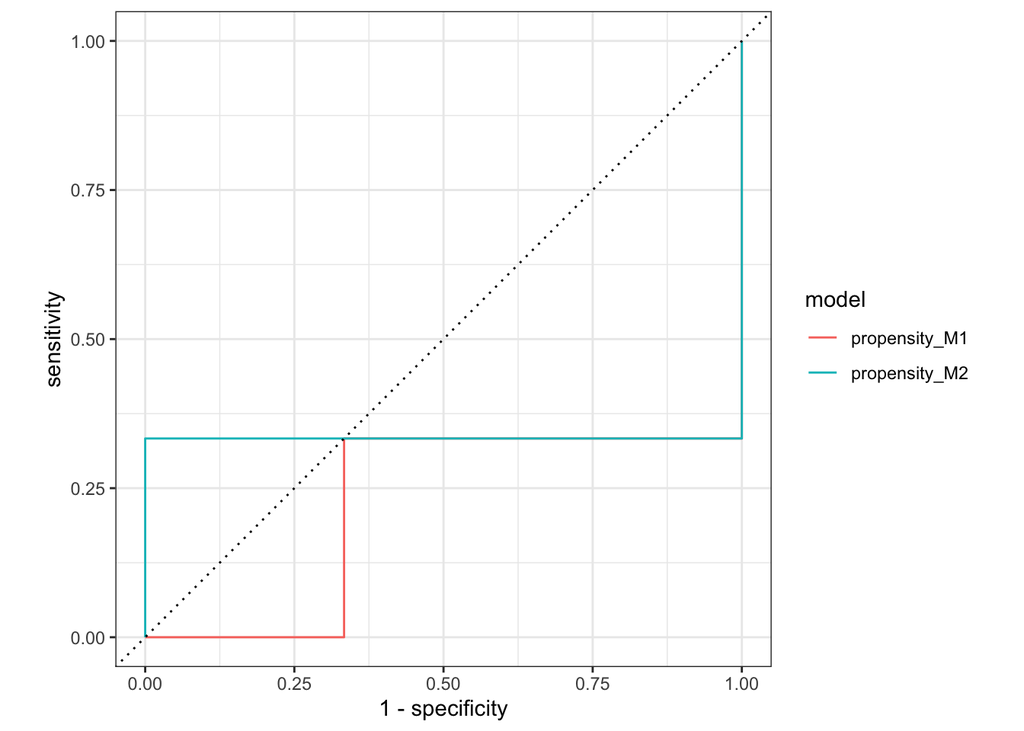

```r
flights_propensity %>%
  pivot_longer(propensity_M1:propensity_M2, names_to = "model", values_to = "propensity") %>%
  group_by(model) %>%
  mutate(actual = as.factor(actual)) %>%
  roc_curve(actual, propensity) %>%
  autoplot()
```

Let’s try to use “delayed” as the positive case. Now the ROC curves make more sense and M1 is better than M2.

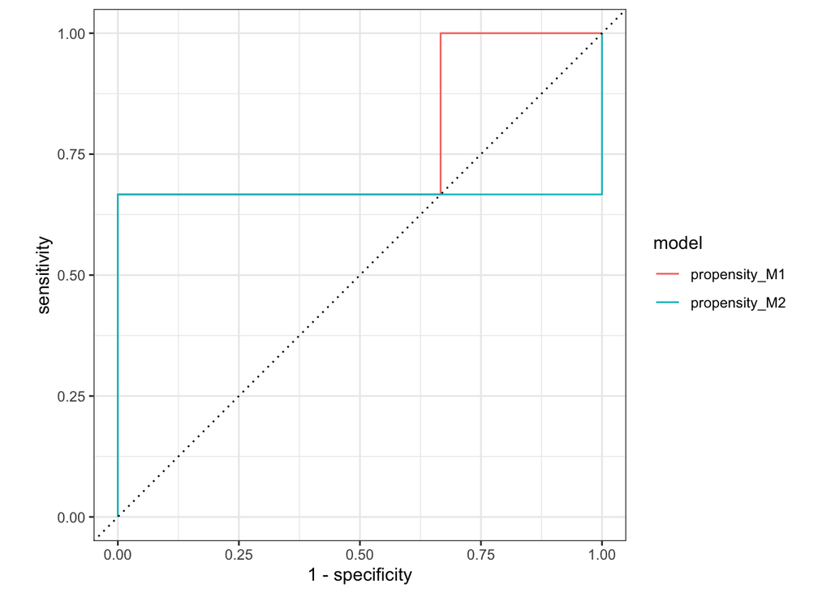

```r
flights_propensity %>%
  pivot_longer(propensity_M1:propensity_M2, names_to = "model", values_to = "propensity") %>%
  mutate(propensity = 1 - propensity) %>%
  group_by(model) %>%
  mutate(actual = as.factor(actual)) %>%
  roc_curve(actual, propensity) %>%
  autoplot()
```

# 4C

Load the data.

```r
library(tidyverse)
flights <- read_csv("https://emitanaka.org/iml/data/FlightDelays.csv") %>%
  select(carrier, dayweek, delay) %>%
  mutate(across(everything(), as.factor),
         delay = relevel(delay, ref = "ontime"))
```

Split the data.

```r
library(rsample)
set.seed(123)
flights_split <- initial_split(flights, prop = 1500/nrow(flights))
flights_train <- training(flights_split)
flights_test <- testing(flights_split)
```

Fit a glm.

```r
glm(delay ~ ., family = binomial, data = flights_train) %>%
  summary()
```

```
##
## Call:
## glm(formula = delay ~ ., family = binomial, data = flights_train)
##
## Deviance Residuals:
##     Min       1Q   Median       3Q      Max
## -0.9429  -0.7196  -0.5275  -0.4001   2.4920
##
## Coefficients:
##              Estimate Std. Error z value Pr(>|z|)
## (Intercept) -0.587845   0.315595  -1.863 0.062511 .
## carrierDH   -0.019002   0.304135  -0.062 0.950183
## carrierDL   -0.909445   0.334473  -2.719 0.006547 **
## carrierMQ   -0.147312   0.326722  -0.451 0.652076
## carrierOH   -0.943767   0.803874  -1.174 0.240386
## carrierRU   -0.226699   0.316166  -0.717 0.473359
## carrierUA   -0.912468   0.682198  -1.338 0.181046
## carrierUS   -1.255172   0.347263  -3.614 0.000301 ***
## dayweek2    -0.437087   0.242134  -1.805 0.071052 .
## dayweek3    -0.609556   0.249196  -2.446 0.014441 *
## dayweek4    -0.641835   0.236889  -2.709 0.006740 **
## dayweek5    -0.404622   0.225955  -1.791 0.073338 .
## dayweek6    -1.561954   0.333803  -4.679 2.88e-06 ***
## dayweek7     0.007492   0.239082   0.031 0.975002
## ---
## Signif. codes:  0 '***' 0.001 '**' 0.01 '*' 0.05 '.' 0.1 ' ' 1
##
## (Dispersion parameter for binomial family taken to be 1)
##
##     Null deviance: 1452.9  on 1499  degrees of freedom
## Residual deviance: 1373.0  on 1486  degrees of freedom
## AIC: 1401
##
## Number of Fisher Scoring iterations: 5
```

I reuse the function from last week. There are some minor adjustments to these functions.

```r
# This returns the x data frame.
# dat: A data frame.
# y_name: A string. Name of y.
dat_get_x <- function(dat, y_name) {

  # Exclude y and any non-numeric variables
  dat[which(names(dat) != y_name)] %>%
    select(where(is.numeric))
}

# This returns the y vector.
# dat: A data frame.
# y_name: A string. Name of y.
dat_get_y <- function(dat, y_name) {
  dat[[y_name]]
}

# This returns a data frame of metrics.
# train_dat: A data frame. The training data.
# test_dat: A data frame. The test data.
# y_name: A string. Name of y.
# alpha: A double. Value of alpha.
# lambda: A double vector. Values of lambda.
# metric: A metric function produced by `yardstick::metric_set`.
train_and_test_glmnet_mod <- function(train_dat,
                                      test_dat,
                                      y_name,
                                      alpha = 1,
                                      lambda = 10 ^ seq(-10, 0, length.out = 50),
                                      metric = metric_set(mae, rmse, mape)) {

  # Fit the model with training data
  mod <- glmnet(x = as.matrix(dat_get_x(train_dat, y_name)),
                y = dat_get_y(train_dat, y_name),
                alpha = alpha,
                lambda = lambda,
                family = "binomial")

  # Get the prediction with test data
  pred <- predict(mod,
                  newx = as.matrix(dat_get_x(test_dat, y_name)),
                  type = "response") %>%
    as.data.frame() %>%

    # Attach the y column
    mutate(truth = dat_get_y(test_dat, y_name)) %>%
    pivot_longer(-truth, names_to = "lambda", values_to = ".pred") %>%
    mutate(lambda = as.integer(gsub("s", "", lambda)) + 1) %>%
    mutate(lambda = mod$lambda[lambda]) %>%

    # The type = "response" will give the prediction for the second class which is "delay",
    # we need to convert it to the probability of "ontime"
    mutate(.pred = 1- .pred) %>%

    # We also need class prediction
    mutate(.pred_class = levels(dat_get_y(train_dat, y_name))[ifelse(.pred > 0.5, 1, 2)]) %>%
    mutate(.pred_class = factor(.pred_class, levels = levels(dat_get_y(train_dat, y_name))))

  # Evaluate the performance
  pred %>%
    group_by(lambda) %>%

    # Because some metrics ask for probability and some ask for class labels
    # we need to provide the probability in the second argument and
    # the class via the named argument
    metric(truth = truth, .pred, estimate = .pred_class)
}

# This returns a data frame of metrics over many folds of data.
# dat: A data frame.
# y_name: A string. Name of y.
# alpha: A double. Value of alpha.
# lambda: A double vector. Values of lambda.
# metric: A metric function produced by `yardstick::metric_set`.
# v: An integer. Number of folds.
cv_glmnet_mod <- function(dat,
                          y_name,
                          alpha = 1,
                          lambda = 10 ^ seq(-10, 0, length.out = 50),
                          metric = metric_set(mae, rmse, mape),
                          v = 10L) {

  # Get CV folds
  folds <- vfold_cv(dat, v = v)

  # Loop over folds along with their fold IDs
  # map2 function allows you to get a pair of values,
  # which in this case, a fold and its ID.
  # check `help(map2_df)` for more details.
  map2_df(folds$splits, folds$id, function(split, fold_id) {

    # Get the train and test data from the fold
    fold_train <- training(split)
    fold_test <- testing(split)

    # Get the performance and add an ID column
    train_and_test_glmnet_mod(fold_train,
                              fold_test,
                              y_name,
                              alpha,
                              lambda,
                              metric) %>%
      mutate(fold_id = fold_id)
  })
}
```

```r
library(glmnet)
library(recipes)
turn_cat_into_dummies <- recipe(delay ~ ., data = flights_train) %>%
  step_dummy(dayweek, carrier) %>%
  prep()

flights_train_baked <- bake(turn_cat_into_dummies, flights_train)

cv_result <- cv_glmnet_mod(flights_train_baked,
                           "delay",
                           metric = metric_set(bal_accuracy, kap, accuracy, roc_auc, pr_auc))
```

```r
cv_result %>%
  group_by(lambda, .metric) %>%
  summarise(mean = mean(.estimate)) %>%
  group_by(.metric) %>%
  filter(mean == min(mean))
```

```
## # A tibble: 162 × 3
## # Groups:   .metric [5]
##      lambda .metric       mean
##       <dbl> <chr>        <dbl>
##  1 1   e-10 accuracy     0.811
##  2 1   e-10 bal_accuracy 0.5
##  3 1   e-10 kap          0
##  4 1.60e-10 accuracy     0.811
##  5 1.60e-10 bal_accuracy 0.5
##  6 1.60e-10 kap          0
##  7 2.56e-10 accuracy     0.811
##  8 2.56e-10 bal_accuracy 0.5
##  9 2.56e-10 kap          0
## 10 4.09e-10 accuracy     0.811
## # … with 152 more rows
```

The result looks very weird. The `roc_auc` suggests `lambda <= 0.01`

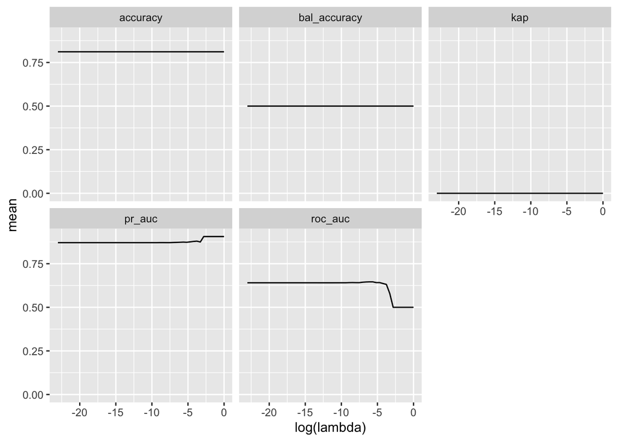

```r
cv_result %>%
  group_by(lambda, .metric) %>%
  summarise(mean = mean(.estimate)) %>%
  ggplot() +
  geom_line(aes(log(lambda), mean)) +
  facet_wrap(~.metric)
```

Let’s have a look at the result produced by `cv.glmnet`. It looks quite similar to our result.

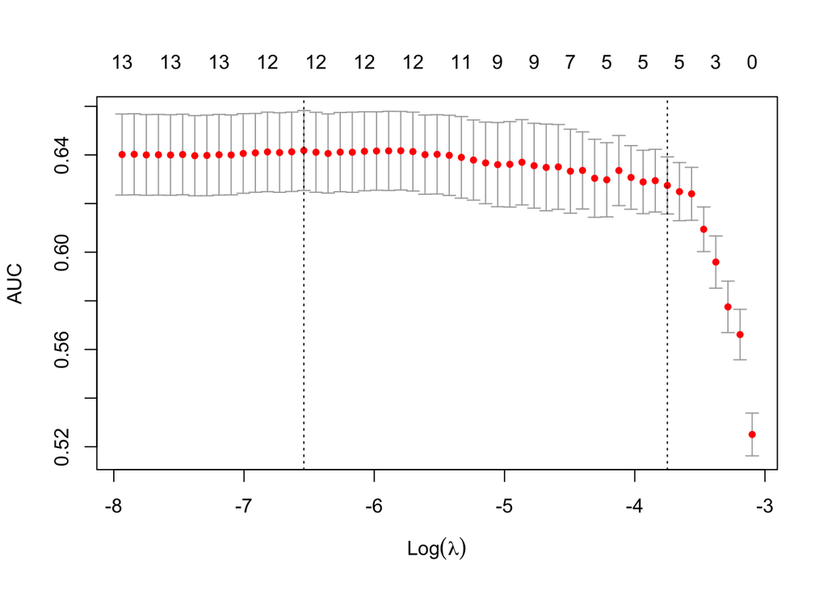

```r
cv.glmnet(x = as.matrix(dat_get_x(flights_train_baked, "delay")),
          y = dat_get_y(flights_train_baked, "delay"),
          type.measure = "auc",
          family = "binomial") %>%
  plot()
```

```r
best_lambda <- cv_result %>%
  group_by(lambda, .metric) %>%
  summarise(mean = mean(.estimate)) %>%
  ungroup() %>%
  filter(.metric == "roc_auc") %>%
  filter(mean == max(mean))
best_lambda
```

```
## # A tibble: 1 × 3
##    lambda .metric  mean
##     <dbl> <chr>   <dbl>
## 1 0.00222 roc_auc 0.646
```

```r
glm(delay ~ ., family = binomial, data = flights_train) %>%

  # This predict the probability of delay, we need to convert it to probability of ontime
  predict(type = "response", newdata = flights_test) %>%
  {roc_auc_vec(truth = flights_test$delay, estimate = 1 - .)}
```

```
## [1] 0.6707083
```

```r
flights_test_baked <- bake(turn_cat_into_dummies, flights_test)

glmnet(as.matrix(dat_get_x(flights_train_baked, "delay")),
       dat_get_y(flights_train_baked, "delay"),
       family = "binomial",
       lambda = best_lambda$mean[1]) %>%

  # This predict the probability of delay, we need to convert it to probability of ontime
  predict(type = "response", newx = as.matrix(dat_get_x(flights_test_baked, "delay"))) %>%
  c() %>%
  {roc_auc_vec(truth = flights_test$delay, estimate = 1 - .)}
```

```
## [1] 0.5
```